# Learner_Notebook

## Unveiling Supermarket Sales

**About Datset**

Inspired by the dataset available at https://www.kaggle.com/aungpyaeap/supermarket-sales, this project delves into the historical sales records of a supermarket company across three branches over a span of three months.

**Overview**

- Conducted comprehensive analysis of a supermarket sales dataset using Pandas and visualization libraries in Python.
- Cleaned the dataset, handled duplicates, and managed missing values for robust analysis.
- Explored distributions, variable relationships, branch-wise sales, gender-based spending patterns, and time trends through EDA.
- Examined correlations between features to unveil underlying relationships within the data.

**Libraries**

Imported necessary libraries for data analysis and visualization:

- pandas for data handling,
- numpy for numerical operations
- matplotlib and seaborn for visualization,
- calmap for calendar heatmaps

```python
import pandas as pd
import numpy as np
import matplotlib.pyplot as plt
import seaborn as sns
import calmap
```

**Initial Data Exploration**

loaded the dataset into a DataFrame (df) using Pandas' read_csv method, then displayed the first and last 10 rows, checked the column names, and examined the data types of each column

```python
df = pd.read_csv('supermarket_sales.csv')
```

```python
df.head(10)
```

|  | Invoice ID | Branch | City | Customer type | Gender | Product line | Unit price | Quantity | Tax 5% | Total | Date | Time | Payment | cogs | gross margin percentage | gross income | Rating |
| --- | --- | --- | --- | --- | --- | --- | --- | --- | --- | --- | --- | --- | --- | --- | --- | --- | --- |
| 0 | 750-67-8428 | A | Yangon | Member | Female | Health and beauty | 74.69 | 7.0 | 26.1415 | 548.9715 | 1/5/19 | 13:08 | Ewallet | 522.83 | 4.761905 | 26.1415 | 9.1 |
| 1 | 226-31-3081 | C | Naypyitaw | Normal | Female | Electronic accessories | 15.28 | 5.0 | 3.8200 | 80.2200 | 3/8/19 | 10:29 | Cash | 76.40 | 4.761905 | 3.8200 | 9.6 |
| 2 | 631-41-3108 | A | Yangon | Normal | Male | Home and lifestyle | 46.33 | 7.0 | 16.2155 | 340.5255 | 3/3/19 | 13:23 | Credit card | 324.31 | 4.761905 | 16.2155 | 7.4 |
| 3 | 123-19-1176 | A | Yangon | Member | Male | Health and beauty | 58.22 | 8.0 | 23.2880 | 489.0480 | 1/27/19 | 20:33 | Ewallet | 465.76 | 4.761905 | 23.2880 | 8.4 |
| 4 | 373-73-7910 | A | Yangon | Normal | Male | Sports and travel | 86.31 | 7.0 | 30.2085 | 634.3785 | 2/8/19 | 10:37 | Ewallet | 604.17 | 4.761905 | 30.2085 | 5.3 |
| 5 | 699-14-3026 | C | Naypyitaw | Normal | Male | Electronic accessories | 85.39 | 7.0 | 29.8865 | 627.6165 | 3/25/19 | 18:30 | Ewallet | 597.73 | 4.761905 | 29.8865 | 4.1 |
| 6 | 355-53-5943 | A | Yangon | Member | Female | NaN | 68.84 | 6.0 | 20.6520 | 433.6920 | 2/25/19 | 14:36 | Ewallet | 413.04 | 4.761905 | 20.6520 | 5.8 |
| 7 | 315-22-5665 | C | Naypyitaw | Normal | Female | NaN | 73.56 | 10.0 | 36.7800 | 772.3800 | 2/24/19 | 11:38 | Ewallet | 735.60 | 4.761905 | 36.7800 | 8.0 |
| 8 | 665-32-9167 | A | Yangon | Member | Female | NaN | 36.26 | 2.0 | 3.6260 | 76.1460 | 1/10/19 | 17:15 | Credit card | 72.52 | 4.761905 | 3.6260 | 7.2 |
| 9 | 692-92-5582 | B | Mandalay | Member | Female | NaN | 54.84 | 3.0 | 8.2260 | 172.7460 | 2/20/19 | 13:27 | Credit card | 164.52 | 4.761905 | 8.2260 | 5.9 |

```python
df.tail(10)
```

|  | Invoice ID | Branch | City | Customer type | Gender | Product line | Unit price | Quantity | Tax 5% | Total | Date | Time | Payment | cogs | gross margin percentage | gross income | Rating |
| --- | --- | --- | --- | --- | --- | --- | --- | --- | --- | --- | --- | --- | --- | --- | --- | --- | --- |
| 993 | 690-01-6631 | B | Mandalay | Normal | Male | Fashion accessories | NaN | 10.0 | 8.7450 | 183.6450 | 2/22/19 | 18:35 | Ewallet | 174.90 | 4.761905 | 8.7450 | 6.6 |
| 994 | 652-49-6720 | C | Naypyitaw | Member | Female | Electronic accessories | NaN | 1.0 | 3.0475 | 63.9975 | 2/18/19 | 11:40 | Ewallet | 60.95 | 4.761905 | 3.0475 | 5.9 |
| 995 | 233-67-5758 | C | Naypyitaw | Normal | Male | Health and beauty | NaN | 1.0 | 2.0175 | 42.3675 | 1/29/19 | 13:46 | Ewallet | 40.35 | 4.761905 | 2.0175 | 6.2 |
| 996 | 303-96-2227 | B | Mandalay | Normal | Female | Home and lifestyle | NaN | 10.0 | 48.6900 | 1022.4900 | 3/2/19 | 17:16 | Ewallet | 973.80 | 4.761905 | 48.6900 | 4.4 |
| 997 | 727-02-1313 | A | Yangon | Member | Male | Food and beverages | NaN | 1.0 | 1.5920 | 33.4320 | 2/9/19 | 13:22 | Cash | 31.84 | 4.761905 | 1.5920 | 7.7 |
| 998 | 347-56-2442 | A | Yangon | Normal | Male | Home and lifestyle | 65.82 | 1.0 | 3.2910 | 69.1110 | 2/22/19 | 15:33 | Cash | 65.82 | 4.761905 | 3.2910 | 4.1 |
| 999 | 849-09-3807 | A | Yangon | Member | Female | Fashion accessories | 88.34 | 7.0 | 30.9190 | 649.2990 | 2/18/19 | 13:28 | Cash | 618.38 | 4.761905 | 30.9190 | 6.6 |
| 1000 | 849-09-3807 | A | Yangon | Member | Female | Fashion accessories | 88.34 | 7.0 | 30.9190 | 649.2990 | 2/18/19 | 13:28 | Cash | 618.38 | 4.761905 | 30.9190 | 6.6 |
| 1001 | 745-74-0715 | A | Yangon | Normal | Male | Electronic accessories | NaN | 2.0 | 5.8030 | 121.8630 | 3/10/19 | 20:46 | Ewallet | 116.06 | 4.761905 | 5.8030 | 8.8 |
| 1002 | 452-04-8808 | B | Mandalay | Normal | Male | Electronic accessories | 87.08 | NaN | 30.4780 | 640.0380 | 1/26/19 | 15:17 | Cash | 609.56 | 4.761905 | 30.4780 | 5.5 |

```python
df.columns
```

```
Index(['Invoice ID', 'Branch', 'City', 'Customer type', 'Gender',
       'Product line', 'Unit price', 'Quantity', 'Tax 5%', 'Total', 'Date',
       'Time', 'Payment', 'cogs', 'gross margin percentage', 'gross income',
       'Rating'],
      dtype='object')
```

```python
df.dtypes
```

```
Invoice ID                  object
Branch                      object
City                        object
Customer type               object
Gender                      object
Product line                object
Unit price                 float64
Quantity                   float64
Tax 5%                     float64
Total                      float64
Date                        object
Time                        object
Payment                     object
cogs                       float64
gross margin percentage    float64
gross income               float64
Rating                     float64
dtype: object
```

**Data Cleaning and Manipulation**

Converted the 'Date' column to a datetime format, set it as the index, removed duplicate rows, and filled missing values with the mean of their respective columns

```python
df['Date'] = pd.to_datetime(df['Date'])
df['Date']
```

```
0      2019-01-05
1      2019-03-08
2      2019-03-03
3      2019-01-27
4      2019-02-08
          ...
998    2019-02-22
999    2019-02-18
1000   2019-02-18
1001   2019-03-10
1002   2019-01-26
Name: Date, Length: 1003, dtype: datetime64[ns]
```

```python
df.dtypes
```

```
Invoice ID                         object
Branch                             object
City                               object
Customer type                      object
Gender                             object
Product line                       object
Unit price                        float64
Quantity                          float64
Tax 5%                            float64
Total                             float64
Date                       datetime64[ns]
Time                               object
Payment                            object
cogs                              float64
gross margin percentage           float64
gross income                      float64
Rating                            float64
dtype: object
```

```python
df.set_index('Date', inplace=True)
```

```python
df.head()
```

| Date | Invoice ID | Branch | City | Customer type | Gender | Product line | Unit price | Quantity | Tax 5% | Total | Time | Payment | cogs | gross margin percentage | gross income | Rating |
| --- | --- | --- | --- | --- | --- | --- | --- | --- | --- | --- | --- | --- | --- | --- | --- | --- |
| 2019-01-05 | 750-67-8428 | A | Yangon | Member | Female | Health and beauty | 74.69 | 7.0 | 26.1415 | 548.9715 | 13:08 | Ewallet | 522.83 | 4.761905 | 26.1415 | 9.1 |
| 2019-03-08 | 226-31-3081 | C | Naypyitaw | Normal | Female | Electronic accessories | 15.28 | 5.0 | 3.8200 | 80.2200 | 10:29 | Cash | 76.40 | 4.761905 | 3.8200 | 9.6 |
| 2019-03-03 | 631-41-3108 | A | Yangon | Normal | Male | Home and lifestyle | 46.33 | 7.0 | 16.2155 | 340.5255 | 13:23 | Credit card | 324.31 | 4.761905 | 16.2155 | 7.4 |
| 2019-01-27 | 123-19-1176 | A | Yangon | Member | Male | Health and beauty | 58.22 | 8.0 | 23.2880 | 489.0480 | 20:33 | Ewallet | 465.76 | 4.761905 | 23.2880 | 8.4 |
| 2019-02-08 | 373-73-7910 | A | Yangon | Normal | Male | Sports and travel | 86.31 | 7.0 | 30.2085 | 634.3785 | 10:37 | Ewallet | 604.17 | 4.761905 | 30.2085 | 5.3 |

**Duplicate values**

```python
df.duplicated()
```

```
Date
2019-01-05    False
2019-03-08    False
2019-03-03    False
2019-01-27    False
2019-02-08    False
              ...
2019-02-22    False
2019-02-18    False
2019-02-18     True
2019-03-10     True
2019-01-26     True
Length: 1003, dtype: bool
```

```python
df.duplicated().sum()
```

```
3
```

```python
df[df.duplicated()==True]
```

| Date | Invoice ID | Branch | City | Customer type | Gender | Product line | Unit price | Quantity | Tax 5% | Total | Time | Payment | cogs | gross margin percentage | gross income | Rating |
| --- | --- | --- | --- | --- | --- | --- | --- | --- | --- | --- | --- | --- | --- | --- | --- | --- |
| 2019-02-18 | 849-09-3807 | A | Yangon | Member | Female | Fashion accessories | 88.34 | 7.0 | 30.919 | 649.299 | 13:28 | Cash | 618.38 | 4.761905 | 30.919 | 6.6 |
| 2019-03-10 | 745-74-0715 | A | Yangon | Normal | Male | Electronic accessories | NaN | 2.0 | 5.803 | 121.863 | 20:46 | Ewallet | 116.06 | 4.761905 | 5.803 | 8.8 |
| 2019-01-26 | 452-04-8808 | B | Mandalay | Normal | Male | Electronic accessories | 87.08 | NaN | 30.478 | 640.038 | 15:17 | Cash | 609.56 | 4.761905 | 30.478 | 5.5 |

```python
df.drop_duplicates(inplace=True)
df.duplicated().sum()
```

```
0
```

**missing values**

```python
df.isna().sum()
```

```
Invoice ID                  0
Branch                      0
City                        0
Customer type              79
Gender                      0
Product line               43
Unit price                  6
Quantity                   19
Tax 5%                      0
Total                       0
Time                        0
Payment                     0
cogs                        0
gross margin percentage     0
gross income                0
Rating                      0
dtype: int64
```

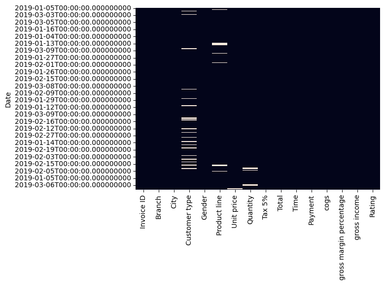

```python
sns.heatmap(df.isnull(),cbar=False)
```

```python
# Replace NaN values in numeric columns with mean
numeric_columns = df.select_dtypes(include='number').columns
df[numeric_columns] = df[numeric_columns].fillna(df[numeric_columns].mean())

# Replace NaN values in categorical columns with mode
categorical_columns = df.select_dtypes(exclude='number').columns
df[categorical_columns] = df[categorical_columns].fillna(df[categorical_columns].mode().iloc[0])
```

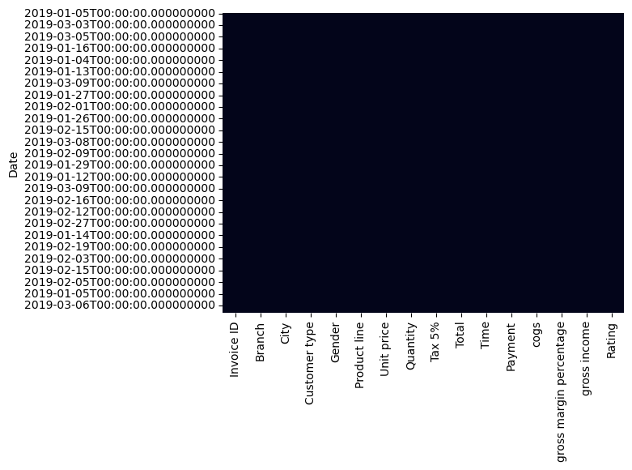

```python
sns.heatmap(df.isnull(),cbar=False)
```

**Understand the distribution of customer ratings and check for skewness**

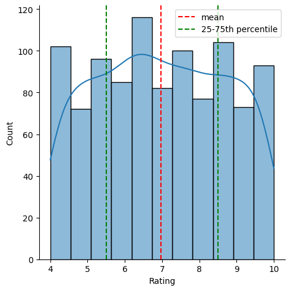

```python
# Visualizing the distribution of customer ratings
sns.displot(df['Rating'], kde=True)
plt.axvline(x=np.mean(df['Rating']), c='red', ls='--', label='mean')
plt.axvline(x=np.percentile(df['Rating'], 25), c='green', ls='--', label='25-75th percentile')
plt.axvline(x=np.percentile(df['Rating'], 75), c='green', ls='--')
plt.legend()
```

Distribution of customer rating looks reletively uniform distribution and there are no left or right skew direction.

**Histogram Analysis:**

```
array([[<Axes: title={'center': 'Unit price'}>,
        <Axes: title={'center': 'Quantity'}>,
        <Axes: title={'center': 'Tax 5%'}>],
       [<Axes: title={'center': 'Total'}>,
        <Axes: title={'center': 'cogs'}>,
        <Axes: title={'center': 'gross margin percentage'}>],
       [<Axes: title={'center': 'gross income'}>,
        <Axes: title={'center': 'Rating'}>, <Axes: >]], dtype=object)
```

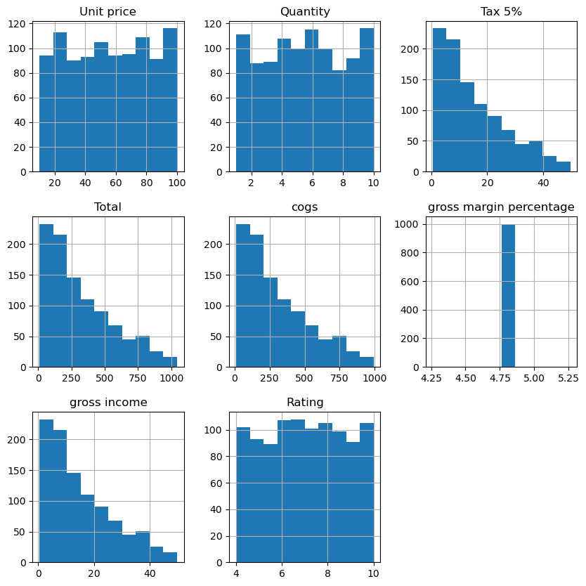

```python
# Generating histograms for various columns in the dataset
df.hist(figsize=(10,10))
```

We observe uniform distribution in unit prices,quantity and rating. The tax distribution skews to the right. The cost margin percentage remains constant. The cost of goods sols, total and gross income are highly correlated.

**Compare sales distribution among different branches and payment methods**

```
object
```

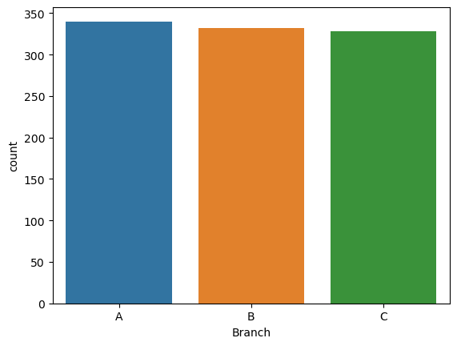

```python
# Visualizing sales counts across branches and payment methods

# Check the data type of 'Branch'
print(df['Branch'].dtype)

# Convert 'Branch' column to categorical type if needed
df['Branch'] = df['Branch'].astype('category')

# Plot the count of branches
sns.countplot(data=df, x='Branch')
plt.show()
```

```python
df['Branch'].value_counts()
```

```
Branch
A    340
B    332
C    328
Name: count, dtype: int64
```

```
object
```

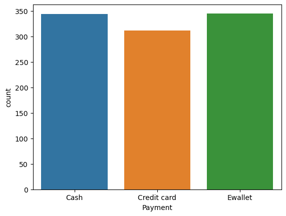

```python
# Check the data type of 'Payment'
print(df['Payment'].dtype)

# Convert 'Payment' column to categorical type if needed
df['Payment'] = df['Payment'].astype('category')

# Plot the count of payment methods
sns.countplot(data=df, x='Payment')
plt.show()
```

```python
df['Payment'].value_counts()
```

```
Payment
Ewallet        345
Cash           344
Credit card    311
Name: count, dtype: int64
```

**Explore the potential connection between customer ratings and gross income**

**Question 3:** Is there a relationship between gross income and customer ratings?

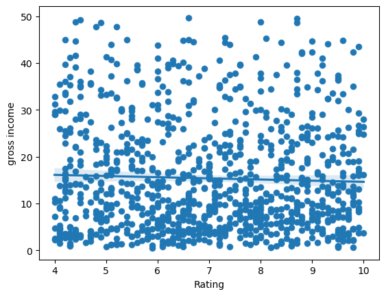

```python
# Examining the relationship between customer ratings and gross income using scatter and regression plots
sns.scatterplot(x=df['Rating'], y=df['gross income'])
sns.regplot(x=df['Rating'], y=df['gross income'])
```

There appears to no influence or relationship between customer rating and gross income.

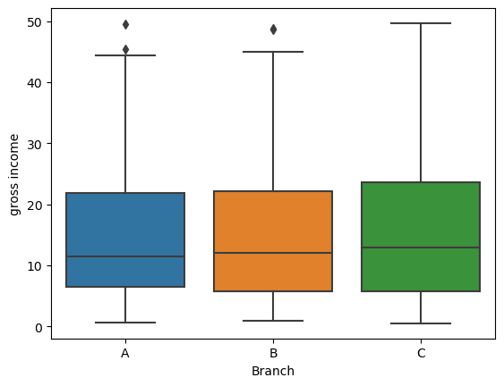

```python
# Analyzing gross income distribution across branches and genders
sns.boxplot(x=df['Branch'], y=df['gross income'])
```

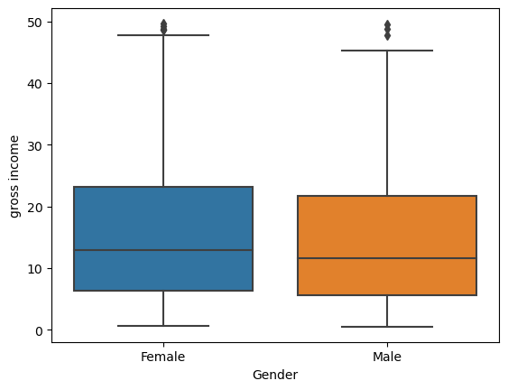

```python
sns.boxplot(x=df['Gender'], y=df['gross income'])
```

It seems that, overall, men and women in this dataset spend about the same. However, at the 75th percentile, women tend to spend more than men.

On average, though, their spending appears to be quite similar.

**Investigate if there's a discernible trend in gross income over time**

```python
df.head()
```

| Date | Invoice ID | Branch | City | Customer type | Gender | Product line | Unit price | Quantity | Tax 5% | Total | Time | Payment | cogs | gross margin percentage | gross income | Rating |
| --- | --- | --- | --- | --- | --- | --- | --- | --- | --- | --- | --- | --- | --- | --- | --- | --- |
| 2019-01-05 | 750-67-8428 | A | Yangon | Member | Female | Health and beauty | 74.69 | 7.0 | 26.1415 | 548.9715 | 13:08 | Ewallet | 522.83 | 4.761905 | 26.1415 | 9.1 |
| 2019-03-08 | 226-31-3081 | C | Naypyitaw | Normal | Female | Electronic accessories | 15.28 | 5.0 | 3.8200 | 80.2200 | 10:29 | Cash | 76.40 | 4.761905 | 3.8200 | 9.6 |
| 2019-03-03 | 631-41-3108 | A | Yangon | Normal | Male | Home and lifestyle | 46.33 | 7.0 | 16.2155 | 340.5255 | 13:23 | Credit card | 324.31 | 4.761905 | 16.2155 | 7.4 |
| 2019-01-27 | 123-19-1176 | A | Yangon | Member | Male | Health and beauty | 58.22 | 8.0 | 23.2880 | 489.0480 | 20:33 | Ewallet | 465.76 | 4.761905 | 23.2880 | 8.4 |
| 2019-02-08 | 373-73-7910 | A | Yangon | Normal | Male | Sports and travel | 86.31 | 7.0 | 30.2085 | 634.3785 | 10:37 | Ewallet | 604.17 | 4.761905 | 30.2085 | 5.3 |

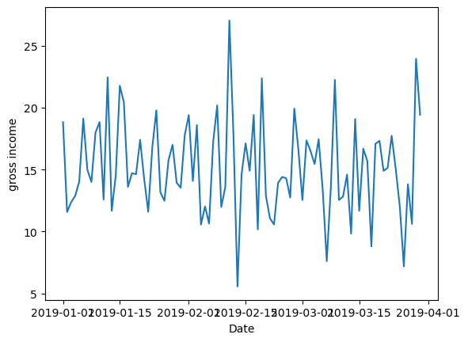

```python
# Convert 'gross income' column to numeric, coercing errors to NaN
df['gross income'] = pd.to_numeric(df['gross income'], errors='coerce')

# Calculate mean of 'gross income' grouped by the index
mean_income = df.groupby(df.index)['gross income'].mean()

# Plot the mean income
sns.lineplot(x=mean_income.index, y=mean_income)
```

**Correlation Analysis**

```python
# Calculates the correlation coefficient between 'gross income' and 'Rating'
round(np.corrcoef(df['gross income'], df['Rating'])[1][0],2)
```

```
-0.04
```

```python
# Computes the correlation matrix for all numerical columns in the DataFrame and rounds the values to two decimal places
# Select only numeric columns
numeric_df = df.select_dtypes(include=np.number)

# Computes the correlation matrix for the selected numeric columns and rounds the values to two decimal places
correlation_matrix = np.round(numeric_df.corr(), 2)
```

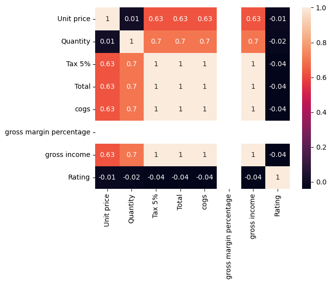

```python
sns.heatmap(correlation_matrix, annot=True)
```